# Some approaches to modeling 1-Year Probability of Default

# Outline

- Modeling Preparation
  - Installing and loading necessary packages
  - Loading the full dataset
  - Exploratory Data Analysis (EDA)
  - Train-Test Split
- Generalized Linear Models (Logistic Regression)
  - Weight of Evidence (WoE) and Information Value (IV)
  - WoE as a data transformation
  - Fitting logistic regression models for 1-year PD (at application)
    - Stepwise logistic regression
    - Multiple factor analysis
  - Score scaling
- Non-linear Models (Random Forest)
  - Fitting a random forest model for 1-year PD (at application)
  - Variable importance in Random Forest
  - Differences with logistic regression approaches

# Preparation

## Installing and loading necessary packages

```r
install.packages(c("tidyverse",
                   "Hmisc",
                   "caret",
                   "car",
                   "scorecard",
                   "randomForest"))
```

```r
library(randomForest)
library(scorecard)
library(car)
library(caret)
library(Hmisc)
library(tidyverse)
```

## Loading the full dataset

```r
demo_data = read_csv("1yrPD_demo_data.csv")
head(demo_data,10)
```

| borrower_id | sex | age_at_application | civil_status | educational_attainment | monthly_income | monthly_amortization | nominal_rate | everbad_in_12mo |
| --- | --- | --- | --- | --- | --- | --- | --- | --- |
| B1 | Male | 31 | Separated | Undergraduate degree holder | 42000 | 3716.792 | 0.05 | 1 |
| B2 | Female | 44 | Single | Undergraduate degree holder | 50000 | 5528.967 | 0.05 | 1 |
| B3 | Female | 47 | Married | Undergraduate degree holder | 51000 | 3583.751 | 0.05 | 1 |
| B4 | Male | 52 | Married | Some college (Not a degree holder) | 54000 | 4437.767 | 0.10 | 0 |
| B5 | Male | 47 | Single | Undergraduate degree holder | 43000 | 4592.664 | 0.10 | 0 |
| B6 | Male | 55 | Single | Undergraduate degree holder | 47000 | 5044.638 | 0.05 | 1 |
| B7 | Male | 44 | Single | Undergraduate degree holder | 57000 | 3021.720 | 0.05 | 1 |
| B8 | Male | 42 | Single | Undergraduate degree holder | 51000 | 4555.489 | 0.05 | 0 |
| B9 | Female | 54 | Single | Some college (Not a degree holder) | 58000 | 4362.629 | 0.10 | 0 |
| B10 | Female | 35 | Separated | Undergraduate degree holder | 43000 | 3664.900 | 0.05 | 0 |

## Exploratory Data Analysis (EDA)

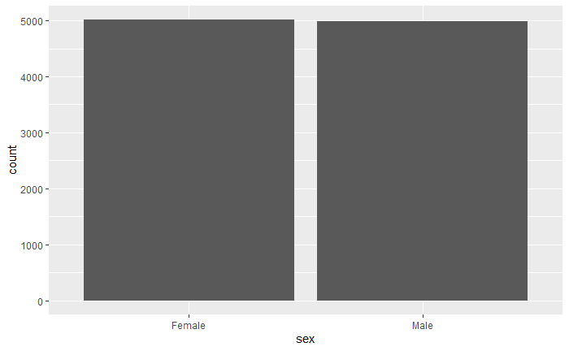

```r
ggplot(data = demo_data, aes(x = sex)) +
  geom_bar()
```

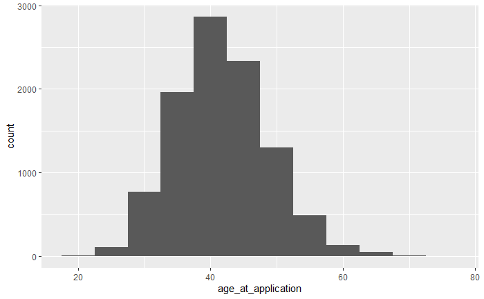

```r
ggplot(data = demo_data, aes(x = age_at_application)) +
  geom_histogram(binwidth = 5)
```

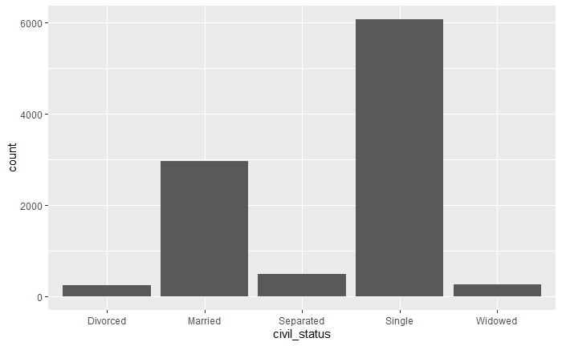

```r
ggplot(data = demo_data, aes(x = civil_status)) +
  geom_bar()
```

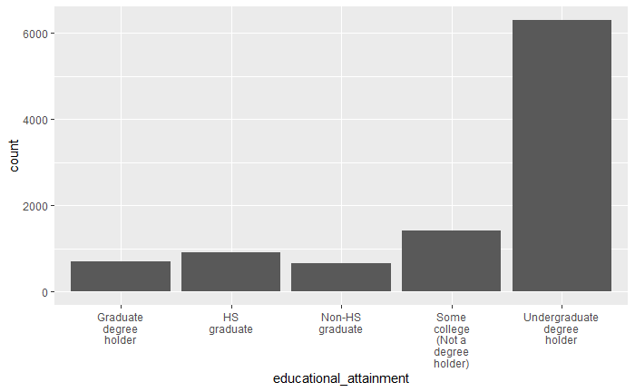

```r
ggplot(data = demo_data, aes(x = educational_attainment)) +
  geom_bar() +
  scale_x_discrete(labels = function(x) str_wrap(x, width = 10))
```

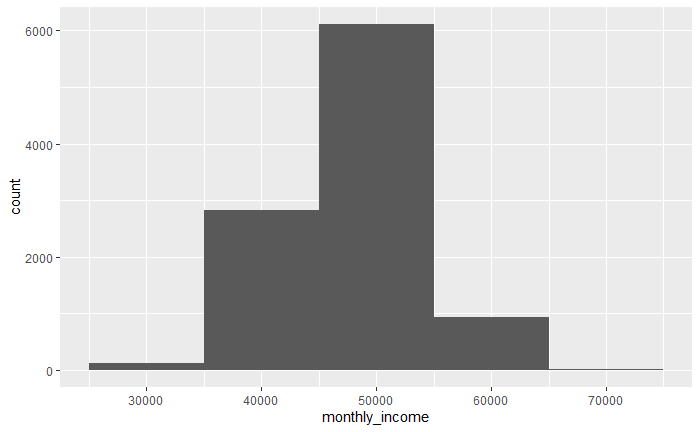

```r
ggplot(data = demo_data, aes(x = monthly_income)) +
  geom_histogram(binwidth = 10000)
```

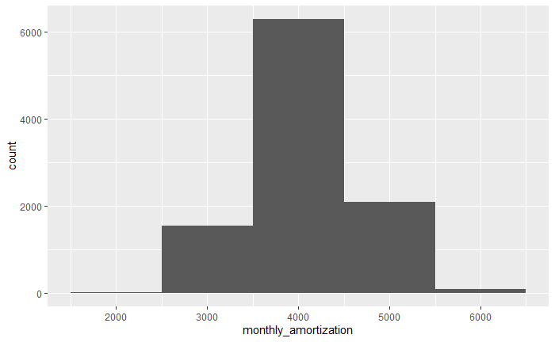

```r
ggplot(data = demo_data, aes(x = monthly_amortization)) +
  geom_histogram(binwidth = 1000)
```

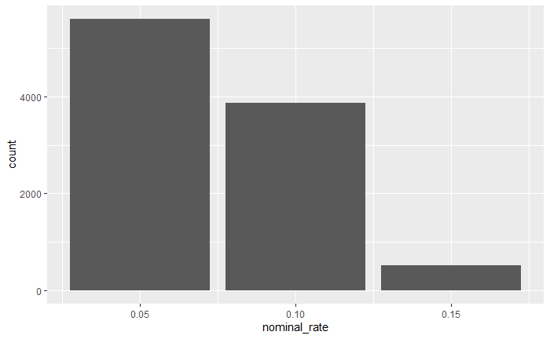

```r
ggplot(data = demo_data, aes(x = nominal_rate)) +
  geom_bar()
```

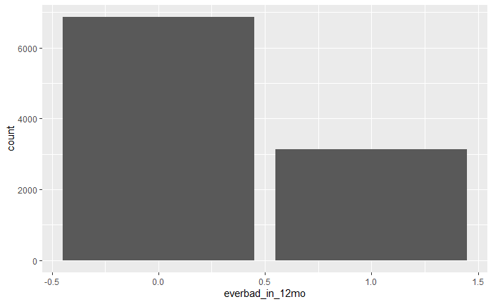

```r
ggplot(data = demo_data, aes(x = everbad_in_12mo)) +
  geom_bar()
```

## Train-Test Split

```r
# set a random seed for reproducible results
set.seed(1234)
training_df = demo_data %>%
  group_by(everbad_in_12mo) %>%
  slice_sample(prop = 0.8) %>%
  ungroup()

test_df = demo_data %>%
  anti_join(training_df)
head(training_df,10)
```

| borrower_id | sex | age_at_application | civil_status | educational_attainment | monthly_income | monthly_amortization | nominal_rate | everbad_in_12mo |
| --- | --- | --- | --- | --- | --- | --- | --- | --- |
| B1431 | Female | 33 | Single | Undergraduate degree holder | 56000 | 3586.377 | 0.05 | 0 |
| B862 | Female | 45 | Single | Some college (Not a degree holder) | 54000 | 4961.744 | 0.10 | 0 |
| B3906 | Female | 45 | Single | Some college (Not a degree holder) | 47000 | 3995.453 | 0.10 | 0 |
| B1324 | Male | 45 | Single | Undergraduate degree holder | 54000 | 4151.772 | 0.05 | 0 |
| B6524 | Female | 41 | Single | Undergraduate degree holder | 52000 | 4596.000 | 0.10 | 0 |
| B4286 | Female | 39 | Single | Some college (Not a degree holder) | 58000 | 4412.118 | 0.10 | 0 |
| B3106 | Female | 46 | Single | Some college (Not a degree holder) | 52000 | 3502.797 | 0.10 | 0 |
| B4617 | Male | 40 | Married | Some college (Not a degree holder) | 48000 | 4488.134 | 0.10 | 0 |
| B4036 | Male | 43 | Married | Undergraduate degree holder | 45000 | 3626.761 | 0.05 | 0 |
| B8325 | Male | 43 | Married | HS graduate | 52000 | 3498.494 | 0.10 | 0 |

```r
head(test_df,10)
```

| borrower_id | sex | age_at_application | civil_status | educational_attainment | monthly_income | monthly_amortization | nominal_rate | everbad_in_12mo |
| --- | --- | --- | --- | --- | --- | --- | --- | --- |
| B5 | Male | 47 | Single | Undergraduate degree holder | 43000 | 4592.664 | 0.10 | 0 |
| B11 | Male | 44 | Single | Graduate degree holder | 51000 | 4051.368 | 0.05 | 0 |
| B15 | Female | 58 | Married | Undergraduate degree holder | 45000 | 4375.676 | 0.05 | 0 |
| B21 | Male | 46 | Separated | Undergraduate degree holder | 46000 | 4106.172 | 0.05 | 0 |
| B28 | Male | 44 | Single | Undergraduate degree holder | 46000 | 4005.094 | 0.05 | 1 |
| B31 | Female | 36 | Single | Undergraduate degree holder | 60000 | 4471.365 | 0.05 | 0 |
| B34 | Male | 57 | Single | Some college (Not a degree holder) | 62000 | 4198.243 | 0.05 | 0 |
| B36 | Male | 36 | Single | Undergraduate degree holder | 43000 | 5282.718 | 0.05 | 0 |
| B41 | Male | 31 | Single | Undergraduate degree holder | 41000 | 3272.967 | 0.05 | 0 |
| B46 | Female | 34 | Single | Undergraduate degree holder | 45000 | 3976.296 | 0.05 | 0 |

# Generalized Linear Models (Logistic Regression)

## Weight of Evidence (WoE) and Information Value (IV)

The Weight of Evidence (WoE) for when a variable $x_{i}$ takes values inside the bin $b_{i,j}$ is defined as

$$\text{WoE}(x_i,b_{i,j}) := \ln\left(\frac{\text{% Goods when variable }x_{i} \text{ is in bin } b_{i,j}}{\text{% Bads when variable }x_{i} \text{ is in bin } b_{i,j}}\right)$$

In some references and implementations of WoE in R (such as in the *woebin* function in the *scorecard* package we will be using), the numerator and denominator inside the $\ln$ is sometimes switched, such that the resulting WoE value is negated. The motivation for the definition with the % Bads in the numerator leads to values that have a positive relationship to the resulting probabilities predicted by the logistic regression model. In turn, said values will have a negative relationship with the resulting scores, since the scores will be scaled such that a higher score corresponds to a lesser probability of default. For us, we will use the definition with the % Goods in the numerator, which will lead to WoE values that have a positive relationship with the resulting scores.

The (total) Information Value (IV) for a variable $x_{i}$ (with the above definition of WoE) is given by

$$\text{IV}(x_{i}) = \sum\limits_{j} \left[\text{WoE}(x_i,b_{i,j})\times\left(\text{% Goods when variable }x_{i} \text{ is in bin } b_{i,j} - \text{% Bads when variable }x_{i} \text{ is in bin } b_{i,j}\right) \right]$$

| IV Range | Strength | Description |
| --- | --- | --- |
| $\text{IV}(x_{i}) \leq 0.01$ | Uncorrelated | Drop, unless sound reason to consider further. |
| $0.01 < \text{IV}(x_{i}) \leq 0.05$ | Very weak | May add value, but can be dropped with minimal loss. |
| $0.05 < \text{IV}(x_{i}) \leq 0.10$ | Weak | Possible spurious correlation, unlikely to feature. |
| $0.10 < \text{IV}(x_{i}) \leq 0.30$ | Medium | Known correlation, which could appear. |
| $0.30 < \text{IV}(x_{i}) \leq 0.50$ | Strong | High information content, and sought after. |
| $0.50 < \text{IV}(x_{i}) \leq 1.00$ | Dominant! | Very powerful, but investigate why. |
| $\text{IV}(x_{i}) > 1.00$ | Warning! | Possible error, perhaps outcome posing as observation. |

```r
# specify manual breaks in the break_list argument
# the set of all possible values for nominal_rate is specified so it can be treated as a categorical variable
# for variables not in breaks_list, woebin automatically determines optimal binnings
# woebin uses woe = ln(Pos_i/Neg_i) by default, which can be changed by setting the positive argument to 0 (0 in everbad_in_12mo means the account was good)
training_woebin = woebin(dt = training_df,
                         y = "everbad_in_12mo",
                         var_skip=c("borrower_id"),
                         breaks_list = list(nominal_rate = c(0.05,0.1,0.15)),
                         positive = 0)
```

```
[INFO] creating woe binning ...
```

```r
training_woebin$sex %>%
  select(variable, bin, breaks, woe, bin_iv, count, count_distr, bads = neg, goods = pos, prob_good = posprob)
```

| variable | bin | breaks | woe | bin_iv | count | count_distr | bads | goods | prob_good |
| --- | --- | --- | --- | --- | --- | --- | --- | --- | --- |
| sex | Male | Male | -0.01621071 | 0.0001321026 | 4009 | 0.5011876 | 1270 | 2739 | 0.6832128 |
| sex | Female | Female | 0.01638734 | 0.0001335420 | 3990 | 0.4988124 | 1236 | 2754 | 0.6902256 |

```r
# summing the bin_iv column from woebin's result gives the (total) IV of the variable
sum(training_woebin$sex$bin_iv)
```

```
[1] 0.0002656446
```

Conclusion: *sex* is an Uncorrelated predictor.

```r
training_woebin$age_at_application %>%
  select(variable, bin, breaks, woe, bin_iv, count, count_distr, bads = neg, goods = pos, prob_good = posprob)
```

| variable | bin | breaks | woe | bin_iv | count | count_distr | bads | goods | prob_good |
| --- | --- | --- | --- | --- | --- | --- | --- | --- | --- |
| age_at_application | [-Inf,34) | 34 | -0.06849799 | 5.410738e-04 | 911 | 0.11388924 | 299 | 612 | 0.6717892 |
| age_at_application | [34,42) | 42 | 0.01387204 | 7.678296e-05 | 3200 | 0.40005001 | 993 | 2207 | 0.6896875 |
| age_at_application | [42,46) | 46 | 0.10592076 | 2.281033e-03 | 1660 | 0.20752594 | 483 | 1177 | 0.7090361 |
| age_at_application | [46,48) | 48 | -0.10068935 | 8.543937e-04 | 662 | 0.08276035 | 222 | 440 | 0.6646526 |
| age_at_application | [48,50) | 50 | -0.26881967 | 4.905420e-03 | 519 | 0.06488311 | 194 | 325 | 0.6262042 |
| age_at_application | [50, Inf) | Inf | 0.05842118 | 4.417920e-04 | 1047 | 0.13089136 | 315 | 732 | 0.6991404 |

```r
# summing the bin_iv column from woebin's result gives the (total) IV of the variable
sum(training_woebin$age_at_application$bin_iv)
```

```
[1] 0.009100496
```

Conclusion: *age_at_application* is an Uncorrelated predictor.

```r
training_woebin$civil_status %>%
  select(variable, bin, breaks, woe, bin_iv, count, count_distr, bads = neg, goods = pos, prob_good = posprob)
```

| variable | bin | breaks | woe | bin_iv | count | count_distr | bads | goods | prob_good |
| --- | --- | --- | --- | --- | --- | --- | --- | --- | --- |
| civil_status | Widowed%,%Divorced%,%Married | Widowed%,%Divorced%,%Married | -0.03868279 | 0.0005277236 | 2801 | 0.3501688 | 901 | 1900 | 0.6783292 |
| civil_status | Single%,%Separated | Single%,%Separated | 0.02107705 | 0.0002875402 | 5198 | 0.6498312 | 1605 | 3593 | 0.6912274 |

```r
# summing the bin_iv column from woebin's result gives the (total) IV of the variable
sum(training_woebin$civil_status$bin_iv)
```

```
[1] 0.0008152639
```

Conclusion: *civil_status* is an Uncorrelated predictor.

```r
training_woebin$educational_attainment %>%
  select(variable, bin, breaks, woe, bin_iv, count, count_distr, bads = neg, goods = pos, prob_good = posprob)
```

| variable | bin | breaks | woe | bin_iv | count | count_distr | bads | goods | prob_good |
| --- | --- | --- | --- | --- | --- | --- | --- | --- | --- |
| educational_attainment | Non-HS graduate | Non-HS graduate | -0.8984117 | 0.057379220 | 511 | 0.06388299 | 270 | 241 | 0.4716243 |
| educational_attainment | HS graduate | HS graduate | -0.5243119 | 0.027830837 | 749 | 0.09363670 | 326 | 423 | 0.5647530 |
| educational_attainment | Some college (Not a degree holder) | Some college (Not a degree holder) | -0.2088085 | 0.006390814 | 1131 | 0.14139267 | 407 | 724 | 0.6401415 |
| educational_attainment | Undergraduate degree holder%,%Graduate degree holder | Undergraduate degree holder%,%Graduate degree holder | 0.2199559 | 0.032455420 | 5608 | 0.70108764 | 1503 | 4105 | 0.7319900 |

```r
# summing the bin_iv column from woebin's result gives the (total) IV of the variable
sum(training_woebin$educational_attainment$bin_iv)
```

```
[1] 0.1240563
```

Conclusion: *educational_attainment* is a Medium predictor.

```r
training_woebin$monthly_income %>%
  select(variable, bin, breaks, woe, bin_iv, count, count_distr, bads = neg, goods = pos, prob_good = posprob)
```

| variable | bin | breaks | woe | bin_iv | count | count_distr | bads | goods | prob_good |
| --- | --- | --- | --- | --- | --- | --- | --- | --- | --- |
| monthly_income | [-Inf,40000) | 40000 | -1.7156762 | 0.193718391 | 481 | 0.06013252 | 345 | 136 | 0.2827443 |
| monthly_income | [40000,47000) | 47000 | -0.5559234 | 0.098955838 | 2361 | 0.29516190 | 1046 | 1315 | 0.5569674 |
| monthly_income | [47000,50000) | 50000 | 0.1736416 | 0.006228109 | 1710 | 0.21377672 | 474 | 1236 | 0.7228070 |
| monthly_income | [50000, Inf) | Inf | 0.6916991 | 0.176414990 | 3447 | 0.43092887 | 641 | 2806 | 0.8140412 |

```r
# summing the bin_iv column from woebin's result gives the (total) IV of the variable
sum(training_woebin$monthly_income$bin_iv)
```

```
[1] 0.4753173
```

Conclusion: *monthly_income* is a Strong predictor.

```r
training_woebin$monthly_amortization %>%
  select(variable, bin, breaks, woe, bin_iv, count, count_distr, bads = neg, goods = pos, prob_good = posprob)
```

| variable | bin | breaks | woe | bin_iv | count | count_distr | bads | goods | prob_good |
| --- | --- | --- | --- | --- | --- | --- | --- | --- | --- |
| monthly_amortization | [-Inf,3300) | 3300 | 0.01321836 | 1.396692e-05 | 641 | 0.08013502 | 199 | 442 | 0.6895476 |
| monthly_amortization | [3300,4300) | 4300 | 0.39428552 | 8.410528e-02 | 4702 | 0.58782348 | 1106 | 3596 | 0.7647809 |
| monthly_amortization | [4300,4700) | 4700 | -0.19429367 | 7.858519e-03 | 1610 | 0.20127516 | 574 | 1036 | 0.6434783 |
| monthly_amortization | [4700,5000) | 5000 | -0.84679677 | 6.099354e-02 | 613 | 0.07663458 | 316 | 297 | 0.4845024 |
| monthly_amortization | [5000, Inf) | Inf | -1.72055857 | 1.753113e-01 | 433 | 0.05413177 | 311 | 122 | 0.2817552 |

```r
# summing the bin_iv column from woebin's result gives the (total) IV of the variable
sum(training_woebin$monthly_amortization$bin_iv)
```

```
[1] 0.3282826
```

Conclusion: *monthly_amortization* is a Strong predictor.

```r
training_woebin$nominal_rate %>%
  select(variable, bin, breaks, woe, bin_iv, count, count_distr, bads = neg, goods = pos, prob_good = posprob)
```

| variable | bin | breaks | woe | bin_iv | count | count_distr | bads | goods | prob_good |
| --- | --- | --- | --- | --- | --- | --- | --- | --- | --- |
| nominal_rate | [-Inf,0.1) | 0.1 | 0.2880807 | 0.04379148 | 4477 | 0.55969496 | 1141 | 3336 | 0.7451418 |
| nominal_rate | [0.1,0.15) | 0.15 | -0.2518123 | 0.02576866 | 3115 | 0.38942368 | 1152 | 1963 | 0.6301766 |
| nominal_rate | [0.15, Inf) | Inf | -0.8782207 | 0.04362854 | 407 | 0.05088136 | 213 | 194 | 0.4766585 |

```r
# summing the bin_iv column from woebin's result gives the (total) IV of the variable
sum(training_woebin$nominal_rate$bin_iv)
```

```
[1] 0.1131887
```

Conclusion: *nominal_rate* is a Medium predictor.

## WoE as a data transformation

```r
training_df_woe = woebin_ply(training_df, training_woebin)
```

```
[INFO] converting into woe values ...
```

```r
head(training_df_woe,10)
```

| borrower_id | everbad_in_12mo | sex_woe | age_at_application_woe | civil_status_woe | educational_attainment_woe | monthly_income_woe | monthly_amortization_woe | nominal_rate_woe |
| --- | --- | --- | --- | --- | --- | --- | --- | --- |
| B1431 | 0 | 0.01638734 | -0.06849799 | 0.02107705 | 0.2199559 | 0.6916991 | 0.3942855 | 0.2880807 |
| B862 | 0 | 0.01638734 | 0.10592076 | 0.02107705 | -0.2088085 | 0.6916991 | -0.8467968 | -0.2518123 |
| B3906 | 0 | 0.01638734 | 0.10592076 | 0.02107705 | -0.2088085 | 0.1736416 | 0.3942855 | -0.2518123 |
| B1324 | 0 | -0.01621071 | 0.10592076 | 0.02107705 | 0.2199559 | 0.6916991 | 0.3942855 | 0.2880807 |
| B6524 | 0 | 0.01638734 | 0.01387204 | 0.02107705 | 0.2199559 | 0.6916991 | -0.1942937 | -0.2518123 |
| B4286 | 0 | 0.01638734 | 0.01387204 | 0.02107705 | -0.2088085 | 0.6916991 | -0.1942937 | -0.2518123 |
| B3106 | 0 | 0.01638734 | -0.10068935 | 0.02107705 | -0.2088085 | 0.6916991 | 0.3942855 | -0.2518123 |
| B4617 | 0 | -0.01621071 | 0.01387204 | -0.03868279 | -0.2088085 | 0.1736416 | -0.1942937 | -0.2518123 |
| B4036 | 0 | -0.01621071 | 0.10592076 | -0.03868279 | 0.2199559 | -0.5559234 | 0.3942855 | 0.2880807 |
| B8325 | 0 | -0.01621071 | 0.10592076 | -0.03868279 | -0.5243119 | 0.6916991 | 0.3942855 | -0.2518123 |

```r
test_df_woe = woebin_ply(test_df, training_woebin)
```

```
[INFO] converting into woe values ...
```

```r
head(test_df_woe,10)
```

| borrower_id | everbad_in_12mo | sex_woe | age_at_application_woe | civil_status_woe | educational_attainment_woe | monthly_income_woe | monthly_amortization_woe | nominal_rate_woe |
| --- | --- | --- | --- | --- | --- | --- | --- | --- |
| B5 | 0 | -0.01621071 | -0.10068935 | 0.02107705 | 0.2199559 | -0.5559234 | -0.19429367 | -0.2518123 |
| B11 | 0 | -0.01621071 | 0.10592076 | 0.02107705 | 0.2199559 | 0.6916991 | 0.39428552 | 0.2880807 |
| B15 | 0 | 0.01638734 | 0.05842118 | -0.03868279 | 0.2199559 | -0.5559234 | -0.19429367 | 0.2880807 |
| B21 | 0 | -0.01621071 | -0.10068935 | 0.02107705 | 0.2199559 | -0.5559234 | 0.39428552 | 0.2880807 |
| B28 | 1 | -0.01621071 | 0.10592076 | 0.02107705 | 0.2199559 | -0.5559234 | 0.39428552 | 0.2880807 |
| B31 | 0 | 0.01638734 | 0.01387204 | 0.02107705 | 0.2199559 | 0.6916991 | -0.19429367 | 0.2880807 |
| B34 | 0 | -0.01621071 | 0.05842118 | 0.02107705 | -0.2088085 | 0.6916991 | 0.39428552 | 0.2880807 |
| B36 | 0 | -0.01621071 | 0.01387204 | 0.02107705 | 0.2199559 | -0.5559234 | -1.72055857 | 0.2880807 |
| B41 | 0 | -0.01621071 | -0.06849799 | 0.02107705 | 0.2199559 | -0.5559234 | 0.01321836 | 0.2880807 |
| B46 | 0 | 0.01638734 | 0.01387204 | 0.02107705 | 0.2199559 | -0.5559234 | 0.39428552 | 0.2880807 |

## Fitting logistic regression models for 1-year PD (at application)

### Stepwise logistic regression

```r
all_vars_model = glm(everbad_in_12mo ~ .,
                     family = binomial(link = 'logit'),
                     data = training_df_woe %>% select(-borrower_id))
summary(all_vars_model)
```

```
Call:
glm(formula = everbad_in_12mo ~ ., family = binomial(link = "logit"),
    data = training_df_woe %>% select(-borrower_id))

Deviance Residuals:
    Min       1Q   Median       3Q      Max
-2.3374  -0.8014  -0.5689   0.9077   2.1736

Coefficients:
                           Estimate Std. Error z value Pr(>|z|)
(Intercept)                -0.78147    0.02679 -29.167  < 2e-16 ***
sex_woe                    -0.34985    1.63993  -0.213   0.8311
age_at_application_woe     -1.21921    0.27680  -4.405 1.06e-05 ***
civil_status_woe           -0.65610    0.93659  -0.701   0.4836
educational_attainment_woe -0.72051    0.12267  -5.874 4.26e-09 ***
monthly_income_woe         -0.98916    0.03913 -25.278  < 2e-16 ***
monthly_amortization_woe   -1.00480    0.04726 -21.260  < 2e-16 ***
nominal_rate_woe           -0.32697    0.12945  -2.526   0.0115 *
---
Signif. codes:  0 ‘***’ 0.001 ‘**’ 0.01 ‘*’ 0.05 ‘.’ 0.1 ‘ ’ 1

(Dispersion parameter for binomial family taken to be 1)

    Null deviance: 9946.1  on 7998  degrees of freedom
Residual deviance: 8450.8  on 7991  degrees of freedom
AIC: 8466.8

Number of Fisher Scoring iterations: 4
```

```r
stepwise_from_all_model = step(all_vars_model, direction = 'both')
```

```
Start:  AIC=8466.77
everbad_in_12mo ~ sex_woe + age_at_application_woe + civil_status_woe +
    educational_attainment_woe + monthly_income_woe + monthly_amortization_woe +
    nominal_rate_woe

                             Df Deviance    AIC
- sex_woe                     1   8450.8 8464.8
- civil_status_woe            1   8451.3 8465.3
<none>                            8450.8 8466.8
- nominal_rate_woe            1   8457.1 8471.1
- age_at_application_woe      1   8470.0 8484.0
- educational_attainment_woe  1   8485.7 8499.7
- monthly_amortization_woe    1   8940.4 8954.4
- monthly_income_woe          1   9151.4 9165.4

Step:  AIC=8464.82
everbad_in_12mo ~ age_at_application_woe + civil_status_woe +
    educational_attainment_woe + monthly_income_woe + monthly_amortization_woe +
    nominal_rate_woe

                             Df Deviance    AIC
- civil_status_woe            1   8451.3 8463.3
<none>                            8450.8 8464.8
+ sex_woe                     1   8450.8 8466.8
- nominal_rate_woe            1   8457.2 8469.2
- age_at_application_woe      1   8470.0 8482.0
- educational_attainment_woe  1   8485.8 8497.8
- monthly_amortization_woe    1   8940.5 8952.5
- monthly_income_woe          1   9151.6 9163.6

Step:  AIC=8463.31
everbad_in_12mo ~ age_at_application_woe + educational_attainment_woe +
    monthly_income_woe + monthly_amortization_woe + nominal_rate_woe

                             Df Deviance    AIC
<none>                            8451.3 8463.3
+ civil_status_woe            1   8450.8 8464.8
+ sex_woe                     1   8451.3 8465.3
- nominal_rate_woe            1   8457.6 8467.6
- age_at_application_woe      1   8470.5 8480.5
- educational_attainment_woe  1   8486.4 8496.4
- monthly_amortization_woe    1   8941.1 8951.1
- monthly_income_woe          1   9152.8 9162.8
```

```r
summary(stepwise_from_all_model)
```

```
Call:
glm(formula = everbad_in_12mo ~ age_at_application_woe + educational_attainment_woe +
    monthly_income_woe + monthly_amortization_woe + nominal_rate_woe,
    family = binomial(link = "logit"), data = training_df_woe %>%
        select(-borrower_id))

Deviance Residuals:
    Min       1Q   Median       3Q      Max
-2.3454  -0.8051  -0.5710   0.9048   2.1655

Coefficients:
                           Estimate Std. Error z value Pr(>|z|)
(Intercept)                -0.78157    0.02679 -29.172  < 2e-16 ***
age_at_application_woe     -1.21905    0.27680  -4.404 1.06e-05 ***
educational_attainment_woe -0.72179    0.12266  -5.885 3.99e-09 ***
monthly_income_woe         -0.98958    0.03912 -25.294  < 2e-16 ***
monthly_amortization_woe   -1.00483    0.04726 -21.263  < 2e-16 ***
nominal_rate_woe           -0.32547    0.12941  -2.515   0.0119 *
---
Signif. codes:  0 ‘***’ 0.001 ‘**’ 0.01 ‘*’ 0.05 ‘.’ 0.1 ‘ ’ 1

(Dispersion parameter for binomial family taken to be 1)

    Null deviance: 9946.1  on 7998  degrees of freedom
Residual deviance: 8451.3  on 7993  degrees of freedom
AIC: 8463.3

Number of Fisher Scoring iterations: 4
```

Note that the *stepwise_from_all_model* has included the variable *age_at_application_woe*, of which the non-transformed version, *age_at_application*, has been deemed as an Uncorrelated predictor earlier.

```r
shortlisted_vars_model = glm(everbad_in_12mo ~ educational_attainment_woe + monthly_income_woe + monthly_amortization_woe + nominal_rate_woe,
                     family = binomial(link = 'logit'),
                     data = training_df_woe)
summary(shortlisted_vars_model)
```

```
Call:
glm(formula = everbad_in_12mo ~ educational_attainment_woe +
    monthly_income_woe + monthly_amortization_woe + nominal_rate_woe,
    family = binomial(link = "logit"), data = training_df_woe)

Deviance Residuals:
    Min       1Q   Median       3Q      Max
-2.3490  -0.8307  -0.5990   0.9026   2.1097

Coefficients:
                           Estimate Std. Error z value Pr(>|z|)
(Intercept)                -0.78137    0.02675 -29.207  < 2e-16 ***
educational_attainment_woe -0.72408    0.12254  -5.909 3.45e-09 ***
monthly_income_woe         -0.98801    0.03907 -25.286  < 2e-16 ***
monthly_amortization_woe   -1.00027    0.04714 -21.217  < 2e-16 ***
nominal_rate_woe           -0.32135    0.12929  -2.486   0.0129 *
---
Signif. codes:  0 ‘***’ 0.001 ‘**’ 0.01 ‘*’ 0.05 ‘.’ 0.1 ‘ ’ 1

(Dispersion parameter for binomial family taken to be 1)

    Null deviance: 9946.1  on 7998  degrees of freedom
Residual deviance: 8470.5  on 7994  degrees of freedom
AIC: 8480.5

Number of Fisher Scoring iterations: 4
```

```r
stepwise_from_shortlisted_model = step(shortlisted_vars_model, direction = 'both')
```

```
Start:  AIC=8480.5
everbad_in_12mo ~ educational_attainment_woe + monthly_income_woe +
    monthly_amortization_woe + nominal_rate_woe

                             Df Deviance    AIC
<none>                            8470.5 8480.5
- nominal_rate_woe            1   8476.6 8484.6
- educational_attainment_woe  1   8505.9 8513.9
- monthly_amortization_woe    1   8957.7 8965.7
- monthly_income_woe          1   9171.3 9179.3
```

```r
summary(stepwise_from_shortlisted_model)
```

```
Call:
glm(formula = everbad_in_12mo ~ educational_attainment_woe +
    monthly_income_woe + monthly_amortization_woe + nominal_rate_woe,
    family = binomial(link = "logit"), data = training_df_woe)

Deviance Residuals:
    Min       1Q   Median       3Q      Max
-2.3490  -0.8307  -0.5990   0.9026   2.1097

Coefficients:
                           Estimate Std. Error z value Pr(>|z|)
(Intercept)                -0.78137    0.02675 -29.207  < 2e-16 ***
educational_attainment_woe -0.72408    0.12254  -5.909 3.45e-09 ***
monthly_income_woe         -0.98801    0.03907 -25.286  < 2e-16 ***
monthly_amortization_woe   -1.00027    0.04714 -21.217  < 2e-16 ***
nominal_rate_woe           -0.32135    0.12929  -2.486   0.0129 *
---
Signif. codes:  0 ‘***’ 0.001 ‘**’ 0.01 ‘*’ 0.05 ‘.’ 0.1 ‘ ’ 1

(Dispersion parameter for binomial family taken to be 1)

    Null deviance: 9946.1  on 7998  degrees of freedom
Residual deviance: 8470.5  on 7994  degrees of freedom
AIC: 8480.5

Number of Fisher Scoring iterations: 4
```

Note that *shortlisted_vars_model* and *stepwise_from_shortlisted_model* are one and the same.

```r
# define a function to evaluate some statistics for a model given the selected independent variables
get_model_stats = function(indep_vars, dep_var, train_data, test_data) {
  lr_formula = paste0(dep_var, " ~ ", paste0(indep_vars, collapse = " + "), " + 1")

  print(lr_formula)

  lr_model = glm(formula = lr_formula,
                 family = binomial(link = 'logit'),
                 data = train_data)

  lr_model_summary = summary(lr_model)
  alias_reindex = ifelse(!lr_model_summary$aliased,cumsum(!lr_model_summary$aliased),NA)
  lr_model_summary_stats = lr_model_summary$coefficients[alias_reindex,]

  if(any(lr_model_summary$aliased)) {
    lr_model_vif = rep(NA,length(indep_vars))
  } else {
    lr_model_vif = vif(lr_model)
  }

  actual_response_train = train_data %>% pull(dep_var)
  pred_prob_train = predict(lr_model,
                            newdata = train_data,
                            type = "response")
  pred_response_train = as.numeric(pred_prob_train >= 0.5)

  conf_mat_train = confusionMatrix(as.factor(pred_response_train),
                                   as.factor(actual_response_train),
                                   positive = "1",
                                   mode = "everything")

  KS_train = ks.test(pred_prob_train[actual_response_train == 0],
                     pred_prob_train[actual_response_train == 1])

  rcorr_train = rcorr.cens(pred_prob_train, actual_response_train)

  actual_response_test = test_data %>% pull(dep_var)
  pred_prob_test = predict(lr_model,
                           newdata = test_data,
                           type = "response")
  pred_response_test = as.numeric(pred_prob_test >= 0.5)

  conf_mat_test = confusionMatrix(as.factor(pred_response_test),
                                  as.factor(actual_response_test),
                                  positive = "1",
                                  mode = "everything")

  KS_test = ks.test(pred_prob_test[actual_response_test == 0],
                    pred_prob_test[actual_response_test == 1])

  rcorr_test = rcorr.cens(pred_prob_test, actual_response_test)

  return_names = c("intercept", paste0("coeff_X", 1:length(indep_vars)),
                   "stderr_intercept", paste0("stderr_X", 1:length(indep_vars)),
                   "z-value_intercept", paste0("z-value_X", 1:length(indep_vars)),
                   "p-value_intercept", paste0("p-value_X", 1:length(indep_vars)),
                   paste0("vif_X", 1:length(indep_vars)),
                   "AIC",
                   "BIC",
                   "train_KS_stat",
                   "train_KS_p-value",
                   paste0("train_", c("AUC", "Gini")),
                   "train_Brier_score",
                   paste0("train_", c("TN", "FP", "FN", "TP")),
                   paste0("train_", names(conf_mat_train$overall)),
                   paste0("train_", names(conf_mat_train$byClass)),
                   "test_KS_stat",
                   "test_KS_p-value",
                   paste0("test_", c("AUC", "Gini")),
                   "test_Brier_score",
                   paste0("test_", c("TN", "FP", "FN", "TP")),
                   paste0("test_", names(conf_mat_test$overall)),
                   paste0("test_", names(conf_mat_test$byClass)))

  c(lr_model_summary_stats[, "Estimate"],
    lr_model_summary_stats[, "Std. Error"],
    lr_model_summary_stats[, "z value"],
    lr_model_summary_stats[, "Pr(>|z|)"],
    lr_model_vif,
    AIC(lr_model),
    BIC(lr_model),
    KS_train$statistic,
    KS_train$p.value,
    rcorr_train[c("C Index","Dxy")],
    mean((pred_prob_train - actual_response_train)^2),
    conf_mat_train$table %>% data.frame %>% arrange(Reference, Prediction) %>% pull(Freq),
    conf_mat_train$overall,
    conf_mat_train$byClass,
    KS_test$statistic,
    KS_test$p.value,
    rcorr_test[c("C Index","Dxy")],
    mean((pred_prob_test - actual_response_test)^2),
    conf_mat_test$table %>% data.frame %>% arrange(Reference, Prediction) %>% pull(Freq),
    conf_mat_test$overall,
    conf_mat_test$byClass) %>% setNames(return_names)
}
```

```r
shortlisted_vars = c("nominal_rate_woe",
                     "educational_attainment_woe",
                     "monthly_income_woe",
                     "monthly_amortization_woe")
get_model_stats(shortlisted_vars,
                "everbad_in_12mo",
                train_data = training_df_woe,
                test_data = test_df_woe) %>%
  t %>%
  data.frame %>%
  cbind(data.frame(X1 = "nominal_rate_woe",
                   X2 = "educational_attainment_woe",
                   X3 = "monthly_income_woe",
                   X4 = "monthly_amortization_woe"),.)
```

```
[1] "everbad_in_12mo ~ nominal_rate_woe + educational_attainment_woe + monthly_income_woe + monthly_amortization_woe + 1"
```

| X1 | X2 | X3 | X4 | intercept | coeff_X1 | coeff_X2 | coeff_X3 | coeff_X4 | stderr_intercept | stderr_X1 | stderr_X2 | stderr_X3 | stderr_X4 | z.value_intercept | z.value_X1 | z.value_X2 | z.value_X3 | z.value_X4 | p.value_intercept | p.value_X1 | p.value_X2 | p.value_X3 | p.value_X4 | vif_X1 | vif_X2 | vif_X3 | vif_X4 | AIC | BIC | … |
| --- | --- | --- | --- | --- | --- | --- | --- | --- | --- | --- | --- | --- | --- | --- | --- | --- | --- | --- | --- | --- | --- | --- | --- | --- | --- | --- | --- | --- | --- | --- |
| nominal_rate_woe | educational_attainment_woe | monthly_income_woe | monthly_amortization_woe | -0.7813705 | -0.3213474 | -0.7240823 | -0.9880074 | -1.000274 | 0.02675262 | 0.1292884 | 0.1225424 | 0.03907271 | 0.047144 | -29.20725 | -2.485508 | -5.908829 | -25.28638 | -21.21743 | 1.569019e-187 | 0.01293668 | 3.445483e-09 | 4.510141e-141 | 6.593586e-100 | 2.728016 | 2.731714 | 1.008383 | 1.008171 | 8480.496 | 8515.432 | … |